# Legal hypergraphs: the paper workflow in honets

honets

2026-09-07

> The sections run in order in a single R session; later ones reuse the objects the earlier ones built. One step per chunk: each chunk saves one object or draws one figure.

Coupette, Hartung and Katz (2024) model legal relations as temporal hypergraphs: a citation block binds every decision it cites to the decision that cites them, and a tribunal binds its three arbitrators for as long as the case runs. The paper works through two datasets, the citation blocks of the German Federal Constitutional Court (GFCC) and the tribunals of the International Centre for Settlement of Investment Disputes (ICSID), and applies three families of methods to them: hyperedge centralities, motifs against a configuration null, and communities of a weighted projection. This vignette reproduces that workflow in honets on the authors’ released data, figure by figure. Hypergraph construction and mathematics are native to honets; once a projection is an ordinary graph, cograph supplies the graph algorithms and the drawing.

## Data

Both datasets ship with honets, rebuilt from the authors’ Zenodo archive (record 8081507, CC BY-NC 4.0) by `data-raw/legal_hypergraphs.R`. `icsid_tribunals` has one row per tribunal seat: the case, the arbitrator who held the seat, the dates on which the tribunal was constituted and the case concluded, and the case metadata. A pending case has no conclusion date.

```r
head(icsid_tribunals)
```

```
#>       case         seat             arbitrator registered constituted
#> 1 ARB/74/1 arbitrator_1 Jacques Michel GROSSEN 1974-03-06  1974-10-07
#> 2 ARB/74/1 arbitrator_2       Dominique PONCET 1974-03-06  1974-10-07
#> 3 ARB/74/1    president           Pierre CAVIN 1974-03-06  1974-10-07
#> 4 ARB/74/2 arbitrator_1           Michael KERR 1974-06-21  1974-12-16
#> 5 ARB/74/2 arbitrator_2           Fuad ROUHANI 1974-06-21  1974-12-16
#> 6 ARB/74/2    president          Jørgen TROLLE 1974-06-21  1974-12-16
#>    concluded is_concluded   economic_sector                           subject
#> 1 1977-08-29         TRUE    Other Industry Production of fibers and textiles
#> 2 1977-08-29         TRUE    Other Industry Production of fibers and textiles
#> 3 1977-08-29         TRUE    Other Industry Production of fibers and textiles
#> 4 1977-02-27         TRUE Oil, Gas & Mining                    Bauxite mining
#> 5 1977-02-27         TRUE Oil, Gas & Mining                    Bauxite mining
#> 6 1977-02-27         TRUE Oil, Gas & Mining                    Bauxite mining
#>      respondent
#> 1 Côte d'Ivoire
#> 2 Côte d'Ivoire
#> 3 Côte d'Ivoire
#> 4       Jamaica
#> 5       Jamaica
#> 6       Jamaica
```

`gfcc_decisions` has one row per decision with its date, and `gfcc_citations` one row per citation: the citing decision, the cited decision, the citation block the citation belongs to, and the dates of both decisions.

```r
head(gfcc_decisions)
```

```
#>   decision       date        citation      type
#> 1  001-001 1951-09-09  BVerfGE 1, 1-3 Beschluss
#> 2  001-003 1951-09-27    BVerfGE 1, 3 Beschluss
#> 3  001-004 1951-09-27  BVerfGE 1, 4-5 Beschluss
#> 4  001-005 1951-09-27  BVerfGE 1, 5-7 Beschluss
#> 5  001-007 1951-10-03  BVerfGE 1, 7-8 Beschluss
#> 6  001-009 1951-10-11 BVerfGE 1, 9-10 Beschluss
#>                                                                                                                                                                                       title
#> 1 Neugliederung im Gebiet der Länder Baden, Württemberg-Baden und Württemberg-Hohenzollern gemäß Art. 118 GG ("Südweststaat" ): Aussetzung der Volksabstimmung durch einstweilige Anordnung
#> 2                                                                                                           Keine Geltendmachung von Schadensersatzansprüchen mittels Verfassungsbeschwerde
#> 3                                                                                                Voraussetzungen der Verfassungsbeschwerde gegen rechtskräftige gerichtliche Entscheidungen
#> 4                                                                                         Keine Verfassungsbeschwerde gegen auf Grund der Entnazifizierungsgesetze ergangene Entscheidungen
#> 5                                                                  Verfassungsbeschwerde gegen rechtskräftige Entscheidungen ordentlicher Gerichte: Umfang der Überprüfung durch das BVerfG
#> 6                                                                   Keine Verfassungsbeschwerde gegen nichtbeschwerdefähige gerichtliche Entscheidungen, die der Urteilsfällung vorausgehen
```

```r
head(gfcc_citations)
```

```
#>    citing   cited       block date_citing date_cited
#> 1 001-001 001-014 001-001:000  1951-09-09 1951-10-23
#> 2 001-005 001-004 001-005:000  1951-09-27 1951-09-27
#> 3 001-066 001-014 001-066:000  1951-10-02 1951-10-23
#> 4 001-074 001-322 001-074:000  1951-11-13 1952-05-28
#> 5 001-085 001-117 001-085:000  1951-11-27 1952-02-20
#> 6 001-202 001-184 001-202:000  1952-03-20 1952-03-20
```

## Models

`temporal_hypergraph()` reads co-presence data the way Dynet does: `actor` names the node column and `group` the column whose shared value binds actors into one hyperedge, here the case. `start` and `end` give the interval on which the hyperedge is active, the paper’s interval-event model. The dates become days since the first constitution, the unit and origin the object reports. A case without a conclusion date stays active through the end of observation, which the paper sets at its cut-off, 2023-06-15; `observation_end` declares that window without rewriting the data. Every other column that is constant within a case, such as the economic sector, is kept as an attribute of the hyperedge; the seat, which varies within a case, is not.

The cut-off is used twice below, so it is one object.

```r
observation_end <- as.Date("2023-06-15")
```

```r
tribunals <- temporal_hypergraph(
  icsid_tribunals, actor = "arbitrator", group = "case",
  start = "constituted", end = "concluded",
  observation_end = observation_end
)
tribunals
```

```
#> Temporal hypergraph: 441 nodes, 742 hyperedges, 1076 event times
#> Format: interval (a hyperedge is active from its start to its end)
#> Time: days since 1974-10-07; observed from 0 to 17783 (declared)
```

`summary()` is the paper’s Table 1 for this dataset.

```r
summary(tribunals)
```

```
#>   n_nodes n_hyperedges n_event_times first_time last_time n_memberships
#> 1     441          742          1076          0     17782          2226
#>   mean_edge_size median_edge_size mean_duration   format time_unit
#> 1              3                3      1303.436 interval      days
```

The citation table is the same shape: the cited decision is the actor and the citation block the group. A block has a single `time`, the date of the decision that contains it, so it is a contact hyperedge: an instantaneous event, as in a contact log. The paper’s point-aggregation model, in which a block stays in the network once it has appeared, is not a property of the data but a way of looking at it, and it is asked for below with `mode = "cumulative"`. The citing decision is constant within a block, so `citing` becomes the block’s attribute. The decision table is the node universe, so that a decision exists from its own date whether or not it has been cited. `sparse = TRUE` stores the 46,257 by 3,618 incidence as a sparse matrix.

```r
blocks <- temporal_hypergraph(
  gfcc_citations, actor = "cited", group = "block", time = "date_citing",
  nodes = gfcc_decisions, sparse = TRUE
)
blocks
```

```
#> Temporal hypergraph: 3618 nodes, 46257 hyperedges, 2026 event times
#> Format: contact (a hyperedge is an instantaneous event; mode = "cumulative" keeps every hyperedge once it appears)
#> Time: days since 1951-09-09; observed from 0 to 25762
```

```r
summary(blocks)
```

```
#>   n_nodes n_hyperedges n_event_times first_time last_time n_memberships
#> 1    3618        46257          2026          0     25762         77284
#>   mean_edge_size median_edge_size mean_duration  format time_unit
#> 1       1.670753                1            NA contact      days
```

The two summaries are the paper’s Table 1: 742 cases with 441 arbitrators and 2,226 memberships, and 46,257 citation blocks with 77,284 memberships over 2,026 decision dates between 1951 and 2022. The paper counts 1,077 event times for ICSID because it adds its cut-off date as the end of every pending case; here those cases have no end.

### Four representations of the same data

`hypergraph_snapshot()` with `mode = "cumulative"` and no `at` returns the static aggregate of a temporal hypergraph, every hyperedge begun by the end of observation, as a `net_hypergraph` that every static verb accepts.

```r
tribunals_all <- hypergraph_snapshot(tribunals, mode = "cumulative")
tribunals_all
```

```
#> Hypergraph: 441 nodes, 742 hyperedges
#> Size distribution:
#>   size_3   : 742
#> Source: group membership (member = member, group = edge)
```

The same call on the citation blocks gives the aggregate citation hypergraph.

```r
blocks_all <- hypergraph_snapshot(blocks, mode = "cumulative")
blocks_all
```

```
#> Hypergraph: 3618 nodes, 46257 hyperedges
#> Size distribution:
#>   size_1   : 30887
#>   size_2   : 7759
#>   size_3   : 3787
#>   size_4   : 1880
#>   size_5   : 922
#>   size_6   : 513
#>   size_7   : 220
#>   size_8   : 130
#>   size_9   : 61
#>   size_10  : 35
#>   size_11  : 26
#>   size_12  : 12
#>   size_13  : 6
#>   size_14  : 5
#>   size_15  : 2
#>   size_16  : 3
#>   size_17  : 3
#>   size_18  : 3
#>   size_19  : 2
#>   size_27  : 1
#> Source: group membership (member = member, group = edge)
```

`hg_representations()` reports an aggregate the four ways the paper’s Table 2 reads it: the multi-hypergraph as it is (`mh`), the binary hypergraph of distinct member sets (`bh`), and the graph the hypergraph reduces to, with (`mg`) or without (`bg`) edge multiplicities. For the tribunals the graph is the clique expansion, in which every pair of members of a tribunal is an edge.

```r
hg_representations(tribunals_all)
```

```
#>   representation       type n_nodes n_edges mean_degree median_degree
#> 1             bg      graph     441    1869    8.476190             4
#> 2             mg      graph     441    2226   10.095238             4
#> 3             bh hypergraph     441     722    4.911565             2
#> 4             mh hypergraph     441     742    5.047619             2
```

For the citation blocks the graph is the citation graph, in which the citing decision is joined to every decision in the block; `graph = "citation"` selects it and `edge_source` names the attribute that holds the citing decision. The multi-graph has five edges fewer than the paper’s 77,284 because five citations repeat a target inside one block, which a graph edge list can hold and a hypergraph incidence cannot, and the binary hypergraph has two member sets fewer for the same reason.

```r
hg_representations(blocks_all, graph = "citation", edge_source = "citing")
```

```
#>   representation       type n_nodes n_edges mean_degree median_degree
#> 1             bg      graph    3618   39428    10.89773            15
#> 2             mg      graph    3618   77279    21.35959            22
#> 3             bh hypergraph    3618   13539    10.15285             6
#> 4             mh hypergraph    3618   46257    21.35959            10
#>   median_out_degree median_in_degree
#> 1                 6                7
#> 2                 9               10
#> 3                NA               NA
#> 4                NA               NA
```

The representation changes what a node looks like: a decision has a median of 6 outgoing citations as a graph node and is a member of a median of 10 blocks as a hypergraph node, and an arbitrator has a median of 4 colleagues but sits on a median of 2 tribunals.

### Decisions as hypergraphs

`hg_subset()` with `where =` keeps the hyperedges whose attribute takes a value, here the blocks of one citing decision: the hypergraph that a single decision is in this model. The decision 153-001 is the headscarf ban; its 68 citation blocks bind 85 cited decisions, 28 of them cited alone.

```r
headscarf <- hg_subset(blocks_all, where = c(citing = "153-001"))
headscarf
```

```
#> Hypergraph: 85 nodes, 68 hyperedges
#> Size distribution:
#>   size_1   : 28
#>   size_2   : 16
#>   size_3   : 9
#>   size_4   : 7
#>   size_5   : 2
#>   size_6   : 3
#>   size_7   : 1
#>   size_8   : 1
#>   size_12  : 1
#> Source: group membership (member = member, group = edge)
```

`plot()` places the cited decisions with a spring layout of the clique projection and draws every block as a blob around its members, coloured by cardinality: the paper’s Figure 3. A decision cited alone is drawn as its node.

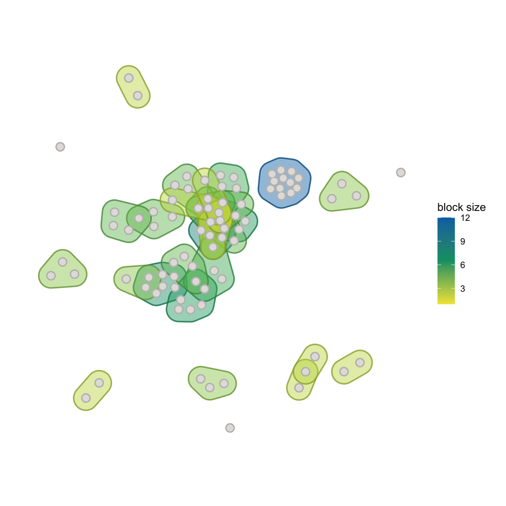

```r
plot(headscarf, color_by = "size", labels = FALSE, padding = 0.035,
     legend_title = "block size")
```

```r
retention <- hg_subset(blocks_all, where = c(citing = "125-260"))
retention
```

```
#> Hypergraph: 56 nodes, 100 hyperedges
#> Size distribution:
#>   size_1   : 61
#>   size_2   : 15
#>   size_3   : 14
#>   size_4   : 8
#>   size_6   : 1
#>   size_7   : 1
#> Source: group membership (member = member, group = edge)
```

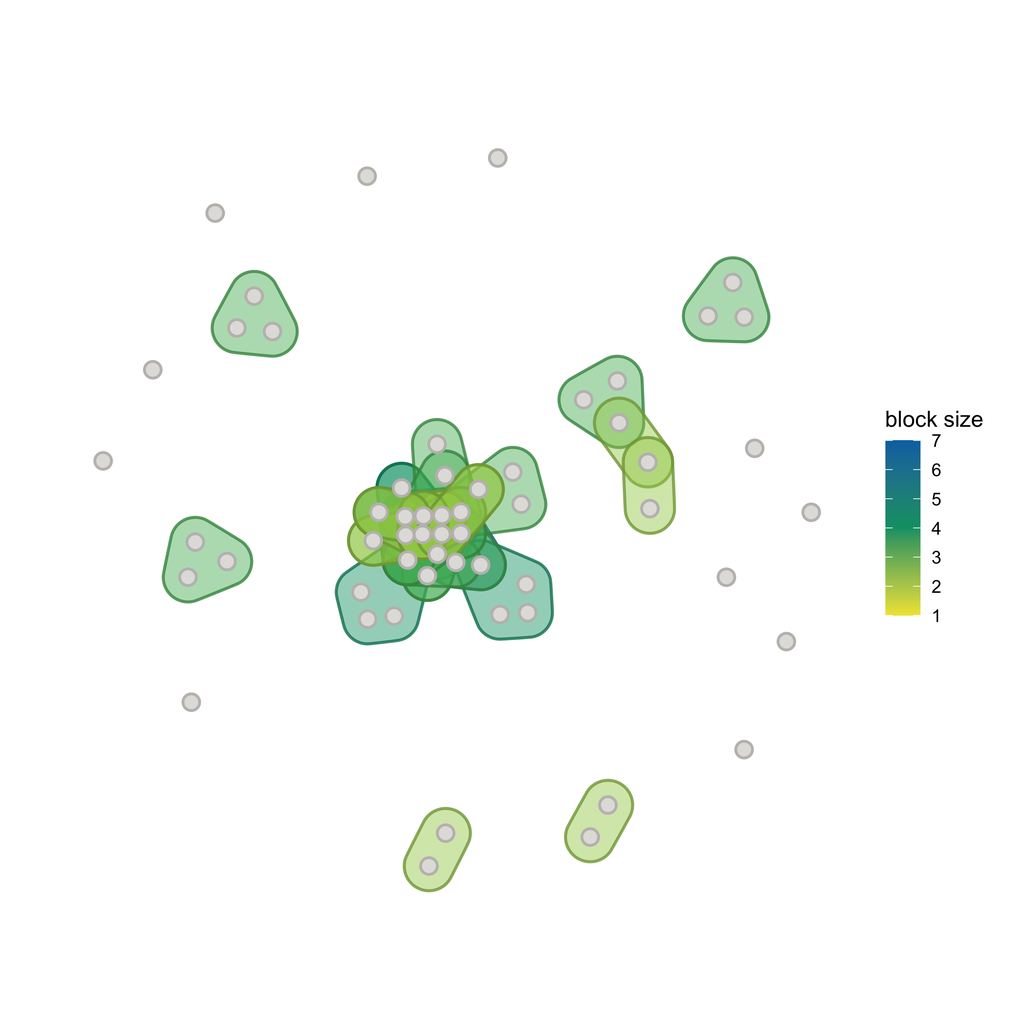

```r
plot(retention, color_by = "size", labels = FALSE, padding = 0.035,
     legend_title = "block size")
```

### Growth

`hg_growth()` counts, at every event time, the nodes and hyperedges present: the hyperedges as they are, the distinct member sets, and the memberships. With `mode = "cumulative"` every count is cumulative and a decision enters at its own date, the paper’s growing citation network. The result is a time series table whose `time` column is on the hypergraph’s clock, days since the first decision; the plot method draws it on the calendar.

```r
growth_blocks <- hg_growth(blocks, mode = "cumulative")
tail(growth_blocks, 3)
```

```
#>       time n_nodes n_edges n_edges_distinct n_memberships
#> 2024 25722    3615   46167            13505         77029
#> 2025 25748    3616   46173            13506         77051
#> 2026 25762    3618   46257            13539         77284
```

Its `plot()` method draws each count against time, the paper’s Figure 4a.

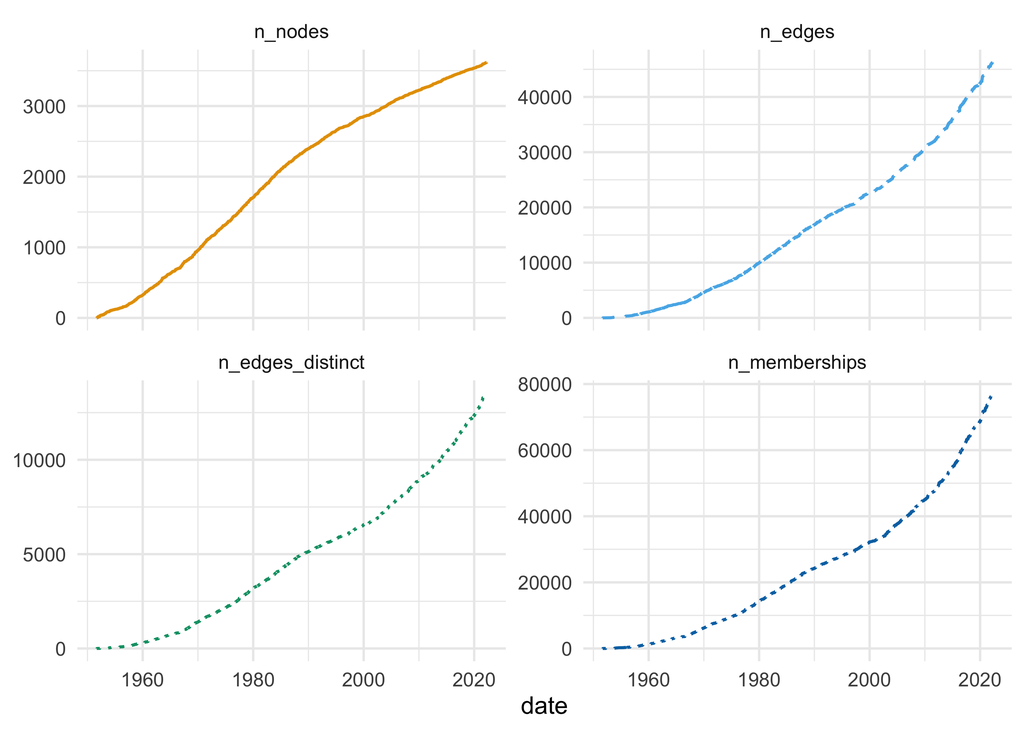

```r
plot(growth_blocks,
     columns = c("n_nodes", "n_edges", "n_edges_distinct", "n_memberships"))
```

`hg_edges()` on a temporal hypergraph evaluates every snapshot requested with `at` (dates are read on the hypergraph’s clock), and `what = "distribution"` returns the empirical distribution of a hyperedge measure with its complementary cumulative share, one block of rows per date. The cumulative mode again gives the network as it stood on each date.

```r
census_dates <- as.Date(c("1960-12-31", "1975-12-31", "1990-12-31",
                          "2005-12-31", "2020-12-31"))
```

```r
sizes_by_date <- hg_edges(blocks, what = "distribution", at = census_dates,
                          snapshot_mode = "cumulative")
head(sizes_by_date)
```

```
#>   time value    n  proportion        ccdf
#> 1 3401     1 1121 0.853769992 1.000000000
#> 2 3401     2  120 0.091393755 0.146230008
#> 3 3401     3   39 0.029702970 0.054836253
#> 4 3401     4   21 0.015993907 0.025133283
#> 5 3401     5    6 0.004569688 0.009139375
#> 6 3401     6    2 0.001523229 0.004569688
```

Its `plot()` draws one curve per date, the paper’s Figure 4b; the distribution shifts to the right as blocks grow longer.

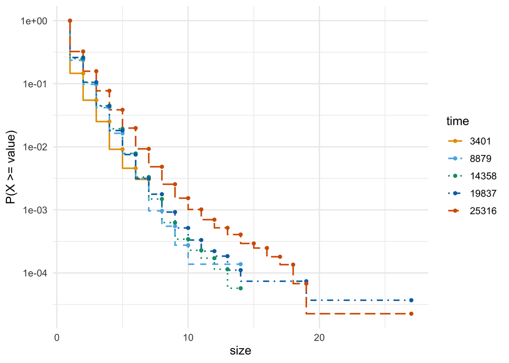

```r
plot(sizes_by_date)
```

The `s` argument counts, for each hyperedge, the other hyperedges that share at least `s` nodes with it. The paper’s Figure 4c draws that count for `s = 2, 3, 4` on the multi-hypergraph.

```r
intersections <- hg_edges(blocks_all, s = 2:4, what = "distribution",
                          measure = "n_incident_edges")
head(intersections)
```

```
#>   s value     n proportion      ccdf
#> 1 2     0 32829 0.70970880 1.0000000
#> 2 2     1  1500 0.03242752 0.2902912
#> 3 2     2  1215 0.02626629 0.2578637
#> 4 2     3  1011 0.02185615 0.2315974
#> 5 2     4   789 0.01705688 0.2097412
#> 6 2     5   692 0.01495990 0.1926844
```

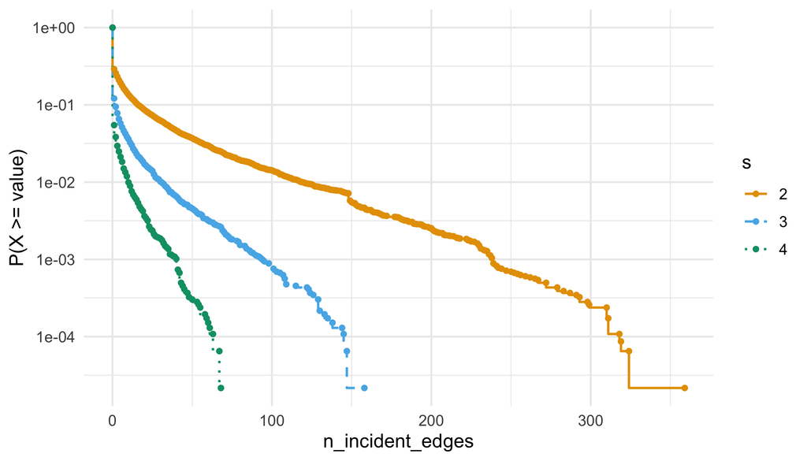

```r
plot(intersections)
```

`multiedges = FALSE` in the snapshot collapses repeated member sets, the binary hypergraph, on which the same counts are smaller.

```r
blocks_binary <- hypergraph_snapshot(blocks, mode = "cumulative",
                                     multiedges = FALSE)
blocks_binary
```

```
#> Hypergraph: 3618 nodes, 13539 hyperedges
#> Size distribution:
#>   size_1   : 2777
#>   size_2   : 4823
#>   size_3   : 2877
#>   size_4   : 1474
#>   size_5   : 754
#>   size_6   : 413
#>   size_7   : 183
#>   size_8   : 112
#>   size_9   : 50
#>   size_10  : 30
#>   size_11  : 17
#>   size_12  : 10
#>   size_13  : 5
#>   size_14  : 4
#>   size_15  : 1
#>   size_16  : 3
#>   size_17  : 2
#>   size_18  : 1
#>   size_19  : 2
#>   size_27  : 1
#> Source: group membership (member = member, group = edge)
```

```r
intersections_binary <- hg_edges(blocks_binary, s = 2:4,
                                 what = "distribution",
                                 measure = "n_incident_edges")
```

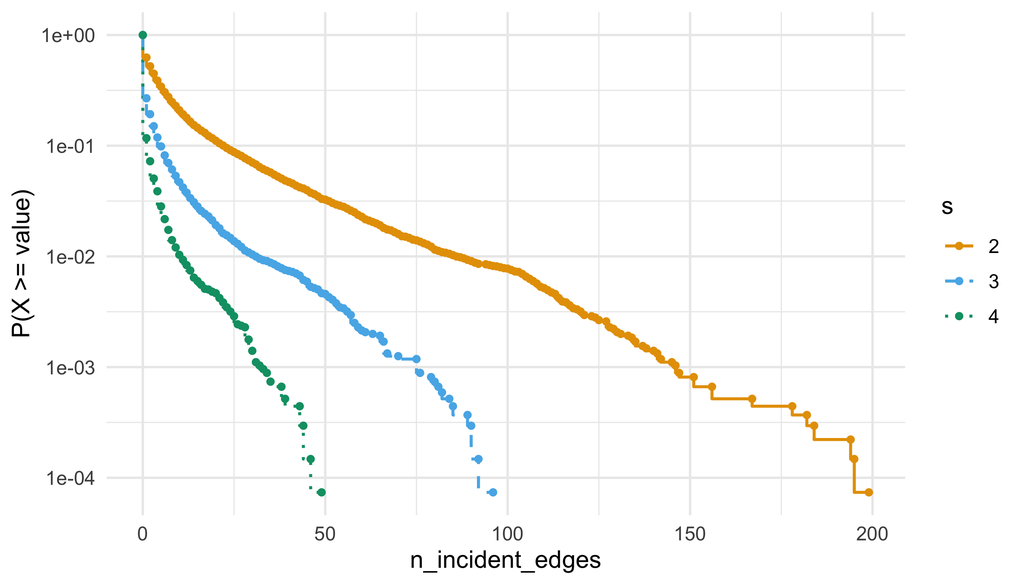

```r
plot(intersections_binary)
```

### Arbitrators and tribunals over time

`hg_measures()` with `what = "distribution"` gives the degree distributions of the paper’s Figure 5a. The number of tribunals an arbitrator sits on is the `hyperdegree`; one arbitrator, Brigitte Stern, sits on 94 tribunals and accounts for the tail.

```r
tribunal_counts <- hg_measures(tribunals_all, what = "distribution",
                               measure = "hyperdegree")
tail(tribunal_counts, 3)
```

```
#>    value n  proportion        ccdf
#> 33    43 1 0.002267574 0.006802721
#> 34    50 1 0.002267574 0.004535147
#> 35    94 1 0.002267574 0.002267574
```

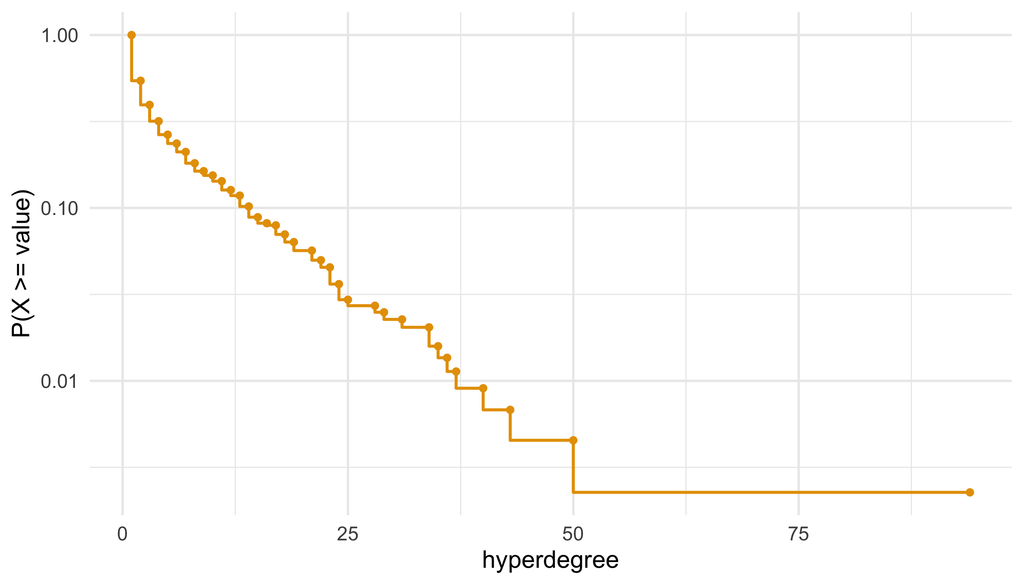

```r
plot(tribunal_counts)
```

For interval data `hg_growth()` reports the active counts and, in the `_cumulative` columns, the counts of a static model that never retires a tribunal.

```r
growth_tribunals <- hg_growth(tribunals)
tail(growth_tribunals, 3)
```

```
#>       time n_nodes n_edges n_edges_distinct n_memberships n_nodes_cumulative
#> 1074 17760     212     210              208           630                441
#> 1075 17777     212     209              207           627                441
#> 1076 17782     210     208              206           624                441
#>      n_edges_cumulative n_edges_distinct_cumulative
#> 1074                742                         722
#> 1075                742                         722
#> 1076                742                         722
```

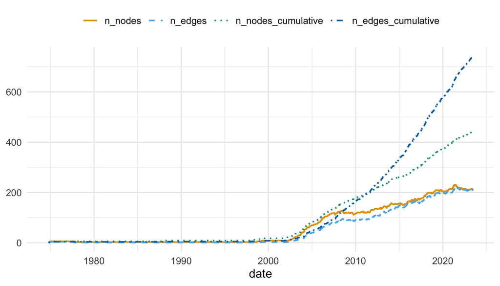

```r
plot(growth_tribunals,
     columns = c("n_nodes", "n_edges", "n_nodes_cumulative", "n_edges_cumulative"),
     facets = FALSE)
```

`hg_edges()` with `what = "summary"` returns, per snapshot, the mean and quartiles of a hyperedge measure. The number of arbitrators within one hop of a tribunal is `n_neighbors`.

```r
neighbourhood <- hg_edges(tribunals, what = "summary", measure = "n_neighbors")
tail(neighbourhood, 3)
```

```
#>       time n_edges     mean       sd min q25 median q75 max
#> 1074 17760     210 24.60000 11.06449   0  17     24  32  54
#> 1075 17777     209 24.28230 10.81762   0  17     24  32  52
#> 1076 17782     208 24.26923 10.79920   0  17     24  32  52
```

The paper’s Figure 5c: the mean and median stay close together, unlike the node degrees above.

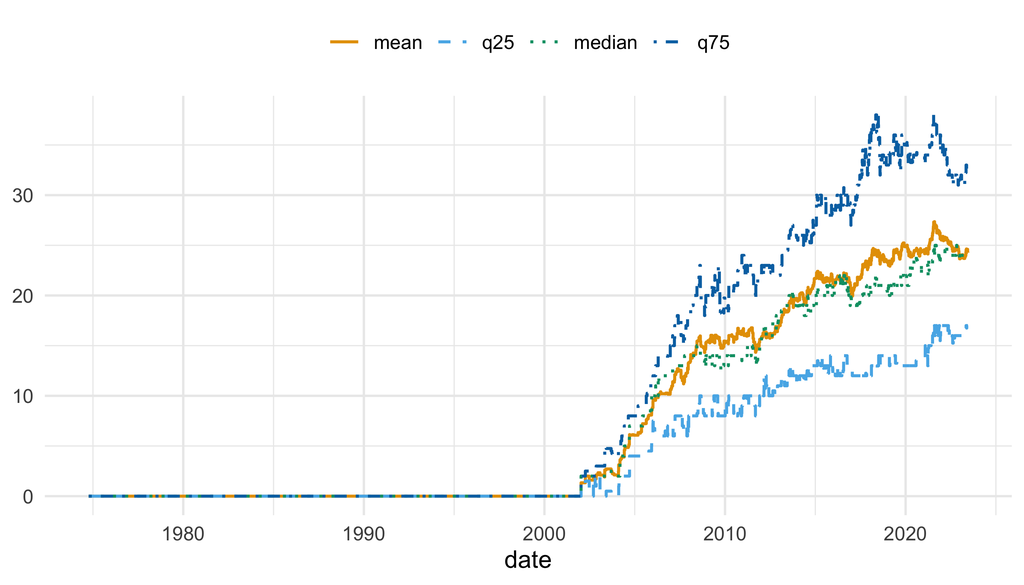

```r
plot(neighbourhood, columns = c("mean", "q25", "median", "q75"), facets = FALSE)
```

`components = TRUE` adds the connectivity of the active hypergraph at each time: the number of components, the share of active arbitrators in the largest, and its diameter. Since 2007 the largest component holds more than 90 percent of the active arbitrators and its diameter stays between 6 and 9, the observation the paper makes in prose.

```r
connectivity <- hg_growth(tribunals, components = TRUE)
tail(connectivity, 3)
```

```
#>       time n_nodes n_edges n_edges_distinct n_memberships n_nodes_cumulative
#> 1074 17760     212     210              208           630                441
#> 1075 17777     212     209              207           627                441
#> 1076 17782     210     208              206           624                441
#>      n_edges_cumulative n_edges_distinct_cumulative n_components
#> 1074                742                         722            4
#> 1075                742                         722            4
#> 1076                742                         722            4
#>      largest_component diameter
#> 1074         0.9575472        7
#> 1075         0.9575472        7
#> 1076         0.9571429        7
```

### Repeated collaborations

`hg_null_test()` compares a statistic with its distribution under a null that preserves every node’s degree and every hyperedge’s size. The `repeated_edges` statistic counts tribunals whose member set already occurred, the paper’s repeated collaboration trios, and `repeated_pairs` the pairs of arbitrators counted with multiplicity minus the distinct pairs, its repeated collaboration pairs. `method = "assignment"` is the paper’s null: arbitrators in decreasing degree each choose their cases without replacement among the cases with a free seat. The 357 repeated pairs and 20 repeated trios lie far above the null (the paper reports z-scores of 4.81 and 10.40 from 1,000 draws).

```r
hg_null_test(tribunals_all, statistic = c("repeated_pairs", "repeated_edges"),
             method = "assignment", n = 999, seed = 1)
```

```
#>        statistic observed  null_mean null_lo null_hi         z p_value   n
#> 1 repeated_pairs      357 299.438438     275     323  4.666061   0.001 999
#> 2 repeated_edges       20   2.612613       0       6 11.149553   0.001 999
#>       method
#> 1 assignment
#> 2 assignment
```

## Methods

### Hyperedge centralities

The centrality analysis of the paper runs on the tribunals active on the last observed date. `hypergraph_snapshot()` with `mode = "active"` returns them, and `multiedges = FALSE` collapses two tribunals with the same three members into one hyperedge.

```r
active <- hypergraph_snapshot(tribunals, at = observation_end,
                              mode = "active", multiedges = FALSE)
active
```

```
#> Hypergraph: 208 nodes, 205 hyperedges
#> Size distribution:
#>   size_3   : 205
#> Source: group membership (member = member, group = edge)
```

`hg_edge_centrality()` builds the s-line graph, in which two hyperedges are adjacent when they share at least `s` nodes, and computes shortest-path betweenness and closeness of the hyperedges on it with the NetworkX normalisation the paper uses. `top = 10` keeps the ten most central cases.

```r
top_betweenness <- hg_edge_centrality(active, s = 1, measure = "betweenness",
                                      top = 10)
top_betweenness
```

```
#>         edge s     measure      value
#> 1  ARB/17/21 1 betweenness 0.02654013
#> 2  ARB/19/27 1 betweenness 0.02499207
#> 3  ARB/18/23 1 betweenness 0.02262065
#> 4  ARB/16/20 1 betweenness 0.02213551
#> 5  ARB/20/19 1 betweenness 0.02206388
#> 6  ARB/18/43 1 betweenness 0.02137011
#> 7   ARB/21/5 1 betweenness 0.02136420
#> 8  ARB/20/53 1 betweenness 0.01910242
#> 9  ARB/20/13 1 betweenness 0.01904040
#> 10 ARB/16/39 1 betweenness 0.01796559
```

`hg_subset()` takes that table and cuts the snapshot down to those cases.

```r
central_tribunals <- hg_subset(active, edges = top_betweenness)
central_tribunals
```

```
#> Hypergraph: 16 nodes, 10 hyperedges
#> Size distribution:
#>   size_3   : 10
#> Source: group membership (member = member, group = edge)
```

`plot()` draws them coloured by economic sector: the paper’s Figure 6a. The names are the archive’s.

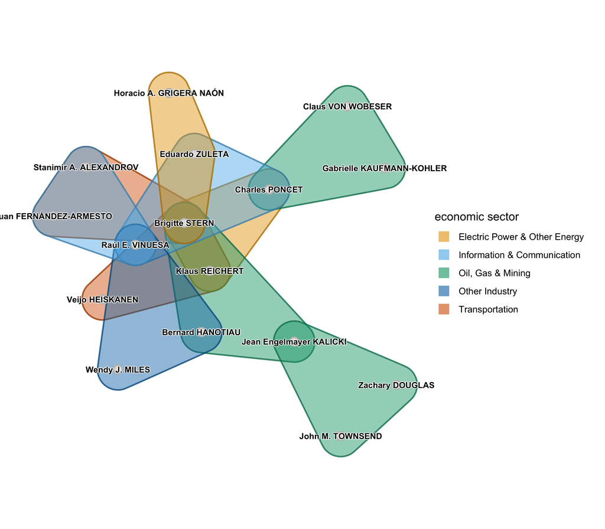

```r
plot(central_tribunals, color_by = "economic_sector",
     legend_title = "economic sector", label_size = 2.8)
```

Closeness ranks a different set of tribunals (Figure 6b).

```r
top_closeness <- hg_edge_centrality(active, s = 1, measure = "closeness",
                                    top = 10)
top_closeness
```

```
#>          edge s   measure     value
#> 1   ARB/18/23 1 closeness 0.4865949
#> 2   ARB/17/21 1 closeness 0.4772147
#> 3   ARB/20/19 1 closeness 0.4760676
#> 4   ARB/21/52 1 closeness 0.4715336
#> 5   ARB/16/39 1 closeness 0.4681894
#> 6    ARB/21/5 1 closeness 0.4616413
#> 7   ARB/22/20 1 closeness 0.4616413
#> 8   ARB/18/32 1 closeness 0.4605677
#> 9   ARB/19/27 1 closeness 0.4573767
#> 10 ADHOC/17/1 1 closeness 0.4552738
```

```r
close_tribunals <- hg_subset(active, edges = top_closeness)
```

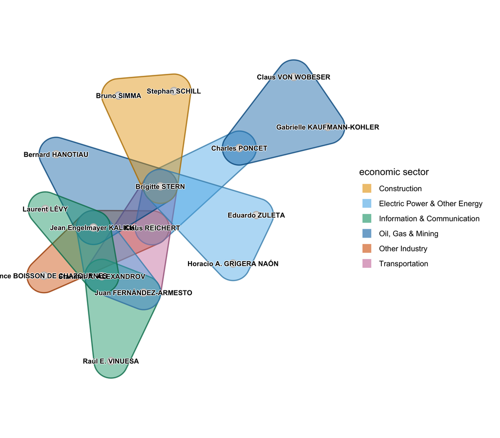

```r
plot(close_tribunals, color_by = "economic_sector",
     legend_title = "economic sector", label_size = 2.8)
```

```r
tribunals_binary <- hypergraph_snapshot(tribunals, mode = "cumulative",
                                        multiedges = FALSE)
tribunals_binary
```

```
#> Hypergraph: 441 nodes, 722 hyperedges
#> Size distribution:
#>   size_3   : 722
#> Source: group membership (member = member, group = edge)
```

On its seven most central cases by closeness, `linetype_by` outlines the concluded cases differently from the pending ones, the distinction the paper draws with dashed and solid lines.

```r
top_aggregate <- hg_edge_centrality(tribunals_binary, s = 1,
                                    measure = "closeness", top = 7)
top_aggregate
```

```
#>        edge s   measure     value
#> 1  ARB/15/5 1 closeness 0.5480570
#> 2 ARB/17/21 1 closeness 0.5472158
#> 3  ARB/14/5 1 closeness 0.5430481
#> 4 ARB/10/21 1 closeness 0.5409880
#> 5 ARB/10/20 1 closeness 0.5397594
#> 6 ARB/12/35 1 closeness 0.5393511
#> 7 ARB/15/32 1 closeness 0.5393511
```

```r
aggregate_tribunals <- hg_subset(tribunals_binary, edges = top_aggregate)
```

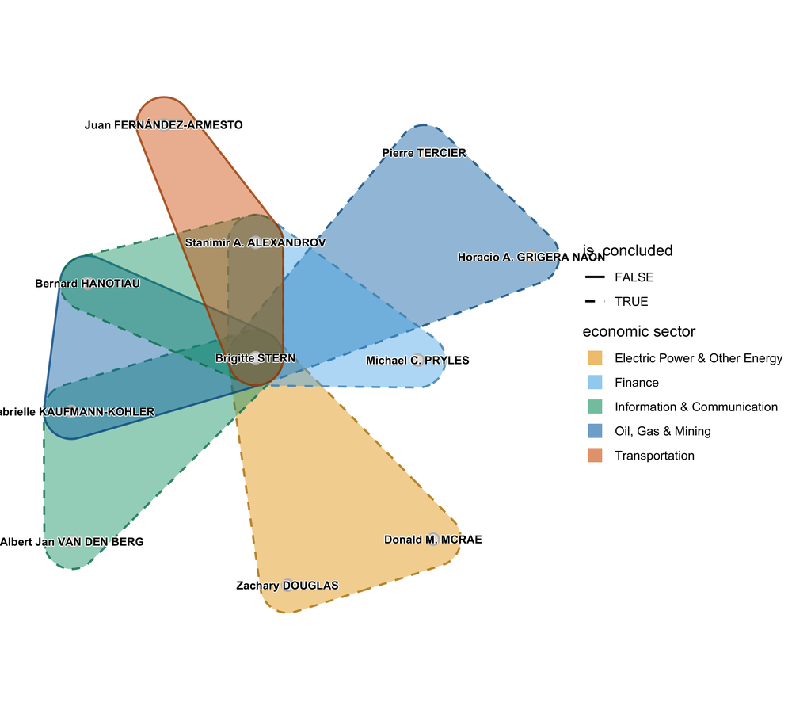

```r
plot(aggregate_tribunals, color_by = "economic_sector",
     linetype_by = "is_concluded",
     legend_title = "economic sector", label_size = 2.8)
```

The paper’s Figure 6c ranks the edges of the temporal graph by ordinary edge betweenness; that is a graph computation on the clique projection, `hg_project(active, method = "clique")`, and is left to a graph engine.

### Motifs

```r
motifs_aggregate <- hg_motifs(tribunals_all, n = 300, seed = 1)
motifs_aggregate
```

```
#>   motif observed   null_mean    null_sd        z     p_value     delta
#> 1     Y      478 291.6066667 20.3490857 9.159789 0.003322259 0.2409407
#> 2     T        7   0.7033333  0.8095197 7.778274 0.003322259 0.5380234
#> 3     O        0   0.0000000  0.0000000       NA 1.000000000 0.0000000
#>   normalized_delta   n             method
#> 1        0.4087138 300 configuration_mcmc
#> 2        0.9126626 300 configuration_mcmc
#> 3        0.0000000 300 configuration_mcmc
```

`plot()` draws the null distribution with the observed count: the paper’s Figure 7c.

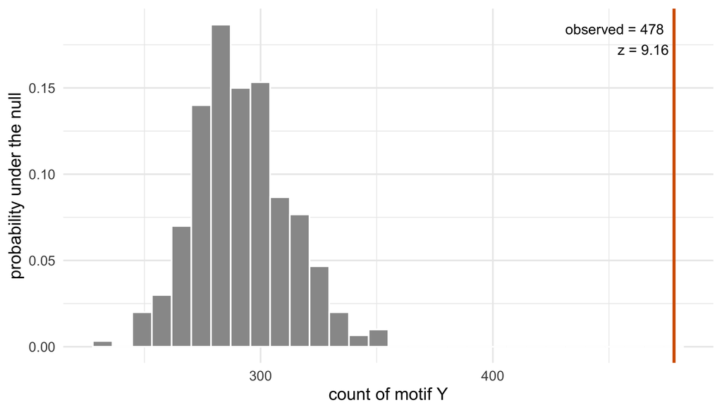

```r
plot(motifs_aggregate)
```

The last snapshot of the temporal hypergraph has far fewer Y motifs, 48, and a smaller but still clear excess over its null (Figure 7b).

```r
motifs_active <- hg_motifs(active, n = 300, seed = 1)
motifs_active
```

```
#>   motif observed   null_mean   null_sd          z     p_value        delta
#> 1     Y       48 25.33000000 5.2543093  4.3145537 0.003322259  0.293159188
#> 2     T        0  0.01333333 0.1146977 -0.1162476 1.000000000 -0.003322259
#> 3     O        0  0.00000000 0.0000000         NA 1.000000000  0.000000000
#>   normalized_delta   n             method
#> 1       0.99993579 300 configuration_mcmc
#> 2      -0.01133188 300 configuration_mcmc
#> 3       0.00000000 300 configuration_mcmc
```

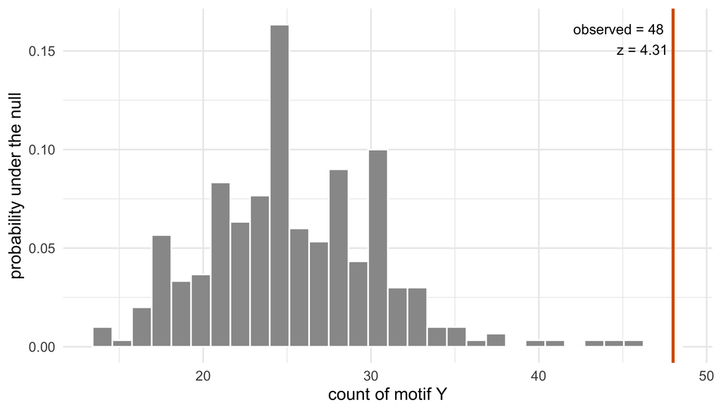

```r
plot(motifs_active)
```

### Communities across representations

The paper clusters the GFCC data eight ways. Four representations are hypergraph-derived: the association graph of `hg_project()`, in which a block of size |e| gives each of its member pairs the weight 1 / (|e| - 1), on the binary (`bh`) or multi (`mh`) hypergraph, with (`bhs`, `mhs`) or without self-association, the term that joins the citing decision to the decisions it cites. Four are classic: the citation graph, binary (`bg`) or multi (`mg`), directed or undirected (`bgu`, `mgu`). The clustering uses backward citations only, those whose citing decision is later than the cited one, so the temporal hypergraph is rebuilt from that subset of the citation table.

```r
backward_citations <- subset(gfcc_citations, date_citing > date_cited)
head(backward_citations)
```

```
#>     citing   cited       block date_citing date_cited
#> 7  001-208 001-097 001-208:000  1952-04-05 1951-12-19
#> 8  001-261 001-184 001-261:000  1952-04-24 1952-03-20
#> 9  001-281 001-085 001-281:000  1952-05-15 1951-11-27
#> 11 001-283 001-184 001-283:000  1952-05-20 1952-03-20
#> 12 001-322 001-009 001-322:000  1952-05-28 1951-10-11
#> 13 001-322 001-074 001-322:001  1952-05-28 1951-11-13
```

```r
backward <- temporal_hypergraph(
  backward_citations, actor = "cited", group = "block",
  time = "date_citing", nodes = gfcc_decisions, sparse = TRUE
)
backward
```

```
#> Temporal hypergraph: 3618 nodes, 46165 hyperedges, 2017 event times
#> Format: contact (a hyperedge is an instantaneous event; mode = "cumulative" keeps every hyperedge once it appears)
#> Time: days since 1951-09-09; observed from 0 to 25762
```

```r
backward_all <- hypergraph_snapshot(backward, mode = "cumulative")
backward_all
```

```
#> Hypergraph: 3618 nodes, 46165 hyperedges
#> Size distribution:
#>   size_1   : 30795
#>   size_2   : 7759
#>   size_3   : 3787
#>   size_4   : 1880
#>   size_5   : 922
#>   size_6   : 513
#>   size_7   : 220
#>   size_8   : 130
#>   size_9   : 61
#>   size_10  : 35
#>   size_11  : 26
#>   size_12  : 12
#>   size_13  : 6
#>   size_14  : 5
#>   size_15  : 2
#>   size_16  : 3
#>   size_17  : 3
#>   size_18  : 3
#>   size_19  : 2
#>   size_27  : 1
#> Source: group membership (member = member, group = edge)
```

`hg_communities()` runs Infomap repeatedly on the chosen projection, compares every pair of partitions with adjusted mutual information and keeps the run with the largest summed AMI as the medoid. The paper uses 50 seeds with 100 trials each; five seeds with five trials are used here to keep the document quick. The eight calls differ only in the projection they ask for. The four classic citation graphs first: `method = "citation"` with `edge_source` naming the citing decision, `duplicate_edges = "collapse"` for the binary graph, `directed = TRUE` for the directed one.

```r
communities_bg <- hg_communities(backward_all, n_runs = 5, trials = 5,
                                 method = "citation", edge_source = "citing",
                                 duplicate_edges = "collapse", directed = TRUE)
communities_bgu <- hg_communities(backward_all, n_runs = 5, trials = 5,
                                  method = "citation", edge_source = "citing",
                                  duplicate_edges = "collapse")
communities_mg <- hg_communities(backward_all, n_runs = 5, trials = 5,
                                 method = "citation", edge_source = "citing",
                                 directed = TRUE)
communities_mgu <- hg_communities(backward_all, n_runs = 5, trials = 5,
                                  method = "citation", edge_source = "citing")
communities_bg
```

```
#> Hypergraph Infomap ensemble: 3618 nodes, 5 runs
#> AMI medoid: run 2 (seed 2), 360 communities
```

Then the four association graphs: the default projection, on the binary or the multi-hypergraph, with or without `self_association`.

```r
communities_bh <- hg_communities(backward_all, n_runs = 5, trials = 5,
                                 duplicate_edges = "collapse")
communities_bhs <- hg_communities(backward_all, n_runs = 5, trials = 5,
                                  duplicate_edges = "collapse",
                                  self_association = TRUE, edge_source = "citing")
communities_mh <- hg_communities(backward_all, n_runs = 5, trials = 5)
communities_mhs <- hg_communities(backward_all, n_runs = 5, trials = 5,
                                  self_association = TRUE, edge_source = "citing")
communities_mhs
```

```
#> Hypergraph Infomap ensemble: 3618 nodes, 5 runs
#> AMI medoid: run 2 (seed 2), 450 communities
```

`hg_compare_communities()` sets the fits side by side. With the hypergraph passed as `hg`, every medoid is also scored on its own projection. The summary counts the communities, singletons and the balance between the two largest clusters of each medoid. The association graphs without self-association leave hundreds of uncited decisions as singletons; with self-association those decisions join the clusters of the decisions they cite, and the largest clusters stay balanced.

```r
comparison <- hg_compare_communities(
  bg = communities_bg, bgu = communities_bgu, mg = communities_mg,
  mgu = communities_mgu, bh = communities_bh, bhs = communities_bhs,
  mh = communities_mh, mhs = communities_mhs, hg = backward_all,
  edge_source = "citing"
)
comparison
```

```
#> Community comparison across 8 representations: bg, bgu, mg, mgu, bh, bhs, mh, mhs
#>  model medoid_seed n_runs n_communities n_singletons n_nontrivial largest
#>     bg           2      5           360          221          139     259
#>    bgu           1      5           330          216          114     363
#>     mg           5      5           406          229          177     108
#>    mgu           5      5           404          216          188     132
#>     bh           2      5           874          664          210     120
#>    bhs           5      5           421          216          205     101
#>     mh           4      5           902          664          238      63
#>    mhs           2      5           450          216          234     102
#>  second   balance
#>     143 0.5521236
#>     190 0.5234160
#>      87 0.8055556
#>      92 0.6969697
#>      91 0.7583333
#>      89 0.8811881
#>      62 0.9841270
#>      87 0.8529412
```

`plot()` draws the cluster-size distributions, the paper’s Figure 8b.

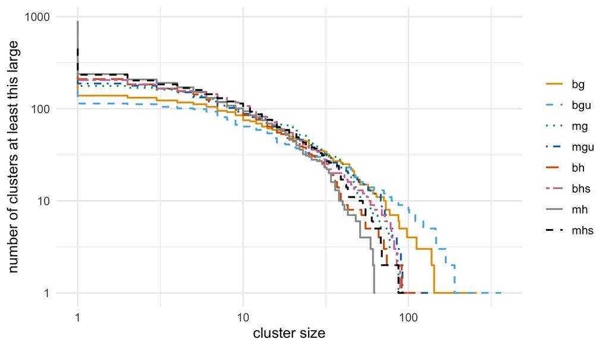

```r
plot(comparison)
```

The similarity table holds the AMI, ARI and NMI between every pair of medoids.

```r
similarity <- as.data.frame(comparison, what = "similarity")
head(similarity)
```

```
#>   model_a model_b n_nodes       ami       ari       nmi
#> 1      bg     bgu    3618 0.6205481 0.4395428 0.7397579
#> 2      bg      mg    3618 0.6584013 0.4212742 0.7874285
#> 3      bg     mgu    3618 0.5949371 0.3931228 0.7466912
#> 4      bg      bh    3618 0.4427375 0.2650922 0.6979714
#> 5      bg     bhs    3618 0.5513407 0.3409745 0.7254793
#> 6      bg      mh    3618 0.4196630 0.2052776 0.6937365
```

`plot(what = "similarity")` is the paper’s Figure 8c with AMI below and ARI above the diagonal. Clusterings of hypergraph-derived representations agree more with each other than with those of the classic graphs.

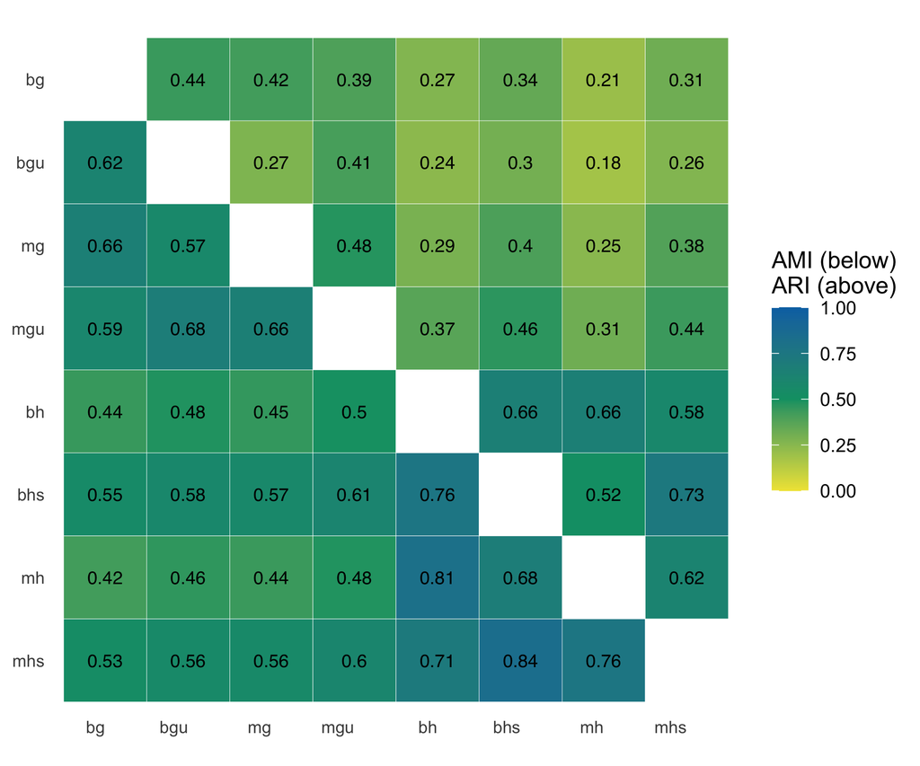

```r
plot(comparison, what = "similarity")
```

The quality table holds the graph-partition diagnostics of the paper for each medoid on its own projection: coverage, weighted coverage, performance, modularity, and the worst community conductance.

```r
quality <- as.data.frame(comparison, what = "quality")
quality
```

```
#>   model  coverage weighted_coverage performance modularity conductance
#> 1    bg 0.3894552         0.3894552   0.9812256  0.3517929   1.0000000
#> 2   bgu 0.4713374         0.4713374   0.9725865  0.4197613   0.8881988
#> 3    mg 0.3107253         0.4943190   0.9881413  0.4729465   1.0000000
#> 4   mgu 0.3582378         0.5497558   0.9874580  0.5251639   0.8372881
#> 5    bh 0.4344190         0.5914135   0.9924775  0.5680416   0.7711864
#> 6   bhs 0.3167942         0.5720922   0.9879647  0.5521826   0.8374632
#> 7    mh 0.3769212         0.6147573   0.9937396  0.5950959   0.8333333
#> 8   mhs 0.2904028         0.6090068   0.9887366  0.5882855   0.8590284
#>   n_communities
#> 1           360
#> 2           330
#> 3           406
#> 4           404
#> 5           874
#> 6           421
#> 7           902
#> 8           450
```

## What the reproduction covers

Every figure and table of the paper that concerns the hypergraphs is produced above from the released data: Table 1 by `summary()`, Table 2 by `hg_representations()`, Figure 3 by `hg_subset()` and `plot()`, Figures 4 and 5 by `hg_growth()`, `hg_edges()` and `hg_measures()`, Figure 6 by `hg_edge_centrality()`, Figure 7 by `hg_motifs()`, Figure 8 by `hg_communities()` and `hg_compare_communities()`, and the repeated collaboration test by `hg_null_test()`. The full-data runner `benchmarks/run_legal_hypergraphs_reproduction.R` checks the association graphs, the archived medoids and the Figure 6 centralities against the authors’ archived results to numerical tolerance: the active betweenness ranking is led by ARB/17/21 at 0.02654013 and the aggregate closeness ranking by ARB/15/5 at 0.54805703, and the motif census of the aggregate is Y = 478, T = 7, O = 0.

## References

Coupette, C., Hartung, D., and Katz, D. M. (2024). Legal hypergraphs. Philosophical Transactions of the Royal Society A, 382(2270), 20230141.

Coupette, C., Hartung, D., and Katz, D. M. (2024). Legal hypergraphs (Software). Zenodo, record 8081507.

Lotito, Q. F., Contisciani, M., De Bacco, C., Di Gaetano, L., Gallo, L., Montresor, A., Musciotto, F., Ruggeri, N., and Battiston, F. (2023). Hypergraphx: a library for higher-order network analysis. Journal of Complex Networks, 11(3), cnad019.

Rosvall, M., and Bergstrom, C. T. (2008). Maps of random walks on complex networks reveal community structure. Proceedings of the National Academy of Sciences, 105(4), 1118-1123.